# Identifying Drivers of Expense Inequity Between Women’s and Men’s Collegiate Basketball

Cameron Jester

05/02/2022

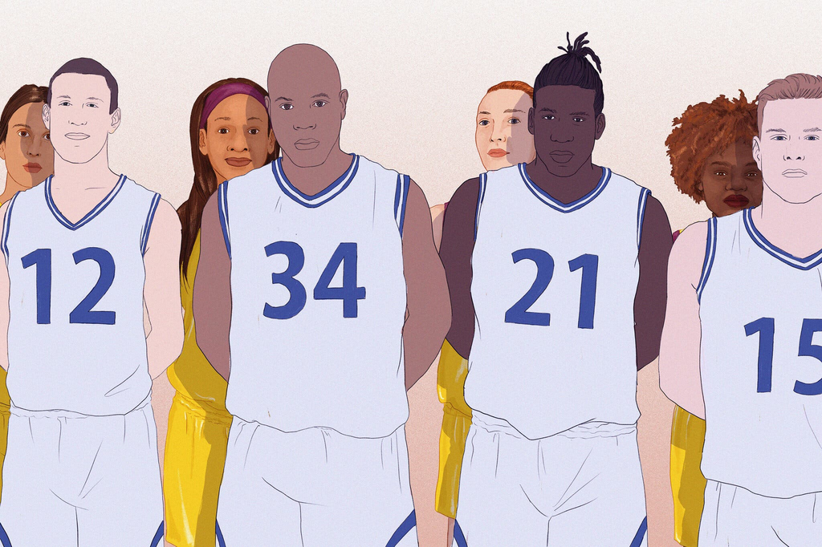

The New York Times, Michelle Kondrich

# Introduction

Hello! Welcome to my project that will outline the data science pipeline, which includes data wrangling/transformation, exploratory analysis, data visualizations, and creating predictive models. I have chosen to use the Collegiate Sports Budget data set from the tidytuesday Github repository. The files can be accessed [here](https://github.com/rfordatascience/tidytuesday/blob/master/data/2022/2022-03-29/readme.md). This data set includes information for 38 collegiate sports across roughly 130,000 schools in the United States.

Expense inequity is an important topic to discuss when working with collegiate sports. The differences in expenditures between men’s and women’s sports teams can be the difference between a winning or losing season. During the 2020 March Madness competition, a [28 second video clip](https://www.youtube.com/watch?v=0SrGB_P3iGU) was released by Sedona Price of the University of Oregon Duck’s. The clip showed the men’s basketball workout facility, which included several weight stations, and state-of-the-art equipment, compared to the singular rack of weights for an entire women’s team. The video sparked meaningful discuss of parity across collegiate sports. One main argument for expenditure for men’s teams being proportional to those of women’s is that women’s teams do not bring in as much revenue. As a former basketball player, advocate for women’s equality, and passionate sports fan, I am diving into the data to see which factors are the most influential drivers of expense inequity between men’s and women’s collegiate basketball.

# Exploratory Data Analysis

My first step of identifying the drivers of expense inequities is to clean, wrangle, and transform my data set into a compatible table to work with. To begin this stage, I filtered for “Basketball” under the ‘sports’ column, which condensed the data to exactly 10,000 schools. I made extensive use of the ‘dplyr’ package by mutating the data to create the following percentages for both the men and women’s teams:

-Participation

-Expenditures

-Revenue

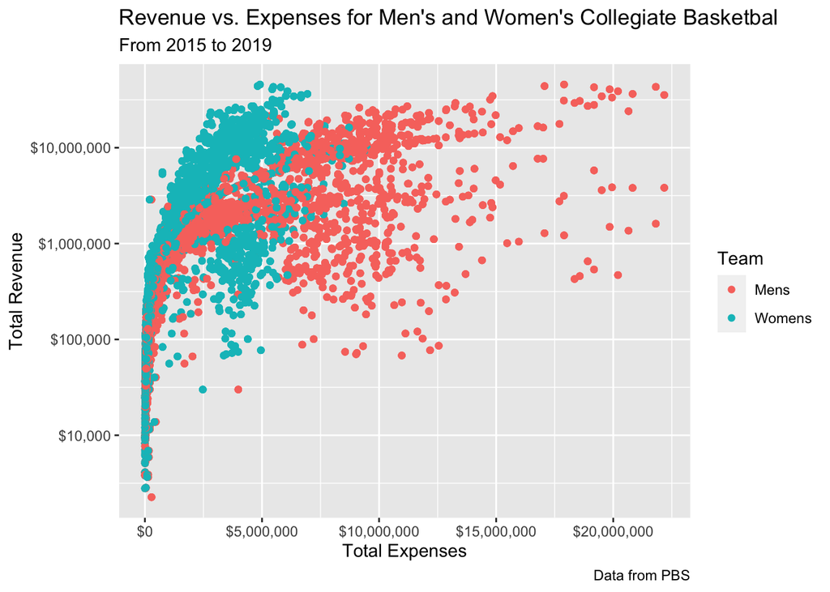

```r
basketball%>%

  ggplot(aes(x= Revenue, y = Expenses, color = Team)) + geom_point()  +  scale_x_log10(labels = dollar) +
  scale_y_continuous(labels = dollar) +  labs(x = "Total Revenue", y = "Total Expenses" , title = "Revenue vs. Expenses for Men's and Women's Collegiate Basketbal", subtitle = "From 2015 to 2019" , caption = "Data from PBS" ) + coord_flip()
```

```r
sports_mutate_wide %>%
  select(institution_name, year, men_percent_expen, women_percent_expen, expense_inequity) %>%
  arrange(desc(expense_inequity)) %>%
  head(10)
```

```
## # A tibble: 10 × 5
##    institution_name      year men_percent_exp… women_percent_e… expense_inequity
##    <chr>                <dbl>            <dbl>            <dbl>            <dbl>
##  1 Simpson University    2019            0.931           0.0695            0.861
##  2 Kent State Universi…  2019            0.898           0.102             0.796
##  3 Patrick Henry Commu…  2019            0.868           0.132             0.735
##  4 Georgetown Universi…  2016            0.865           0.135             0.730
##  5 Palo Verde College    2019            0.853           0.147             0.706
##  6 Villanova University  2018            0.851           0.149             0.703
##  7 Villanova University  2017            0.848           0.152             0.696
##  8 Creighton University  2019            0.840           0.160             0.681
##  9 Creighton University  2017            0.836           0.164             0.672
## 10 American University…  2018            0.834           0.166             0.668
```

The table above shows the schools with the largest difference between men’s and women’s basketball expenditures. Half of the schools with the largest expense inequity were documented in 2019, just one year prior to Sedona Price sharing the viral March Madness video.

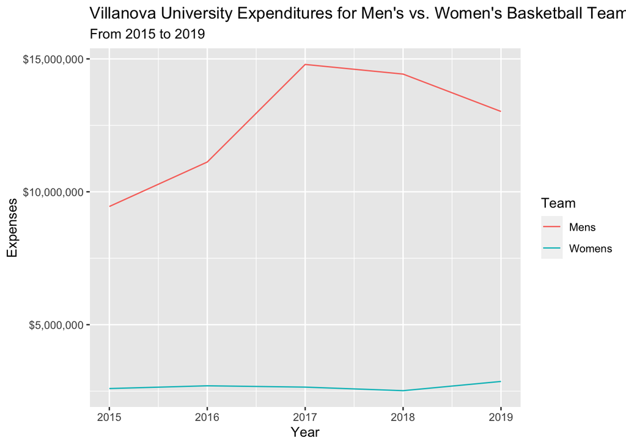

```r
sports_mutate_wide %>%
  filter(institution_name %in% c("Villanova University")) %>%
  pivot_longer(names_to = "Team", values_to = "Expenses", cols = Mens:Womens) %>%
  ggplot(aes(x = year, y = Expenses, color = Team)) + geom_line() +
  scale_y_continuous(labels = dollar) + labs(title = "Villanova University Expenditures for Men's vs. Women's Basketball Teams", subtitle = "From 2015 to 2019", x = "Year")
```

Shockingly Villanova University made the list twice. Villanova is a consistent contender in March Madness for both their men and women’s teams. Depsite this, over 5 years their expenditure for their women’s team is consistently much lower than their men’s teams.

# Machine learning

As mentioned in the Introduction, one of the arguments supporting the gap in expense between men’s and women’s basketball teams is the amount of revenue the respective teams bring in. While there is no dispute on whether that is true ([Men’s March Madness generated $1.8 billion](https://www.sportico.com/leagues/college-sports/2022/march-madness-daily-the-ncaas-billion-dollar-cash-cow-1234668823/) which [compares to Women’s $34 million](https://www.forbes.com/sites/kristidosh/2022/03/31/ncaa-bullish-on-change-for-womens-basketball-tournament-revenue-and-distribution/?sh=7ade79342303) ) , using machine learning may help us determine if that is the only *major* indicator of expenditures.

```r
set.seed(0510)
womens_split = initial_split(womens_basketball, prop = 0.7)
womens_train = training(womens_split)
womens_test = testing(womens_split)

set.seed(0510)
mens_split = initial_split(mens_basketball, prop = 0.7)
mens_train = training(mens_split)
mens_test = testing(mens_split)
```

To begin the modeling process, the data had to be split into men’s and women’s tables. Then, training and testing sets were created for both tables, which were used to fit multiple regression models. Following the fitting process came predicting values and calculating an rMSE for each model.

```r
lm_womens_fit = lm_spec %>%
  fit(exp_women ~ rev_women  + ef_female_count + partic_women + women_percent_partic   + women_percent_rev , data = womens_train)


lm_pred_test_womens = lm_womens_fit %>%
  predict(new_data = womens_test)


womens_test %>%
  select(exp_women, rev_women) %>%
  mutate(expense_women_pred = lm_pred_test_womens$.pred) %>%
  rmse(truth = exp_women, estimate = expense_women_pred)
```

```
## # A tibble: 1 × 3
##   .metric .estimator .estimate
##   <chr>   <chr>          <dbl>
## 1 rmse    standard     428270.
```

```r
#womens_test
```

```r
lm_mens_fit = lm_spec %>%
  fit(exp_men ~ rev_men  + ef_male_count + partic_men + men_percent_partic + men_percent_rev , data = mens_train)


lm_pred_test_mens= lm_mens_fit %>%
  predict(new_data = mens_test)


mens_test %>%
  select(exp_men, rev_men) %>%
  mutate(expense_men_pred = lm_pred_test_mens$.pred) %>%
  rmse(truth = exp_men, estimate = expense_men_pred)
```

```
## # A tibble: 1 × 3
##   .metric .estimator .estimate
##   <chr>   <chr>          <dbl>
## 1 rmse    standard     611419.
```

```r
#mens_test
```

The second type of model used in this analysis is a decision tree model.

```r
set.seed(0510)
womens_tree = decision_tree()%>%
  set_mode(mode = "regression") %>%
  fit(exp_women ~ rev_women + ef_female_count + partic_women + women_percent_partic   + women_percent_rev , data = womens_train)



tree_pred_test_womens= womens_tree %>%
  predict(new_data = womens_test)



womens_test %>%
  mutate(expense_women_pred = tree_pred_test_womens$.pred) %>%
  rmse(truth = exp_women, estimate = expense_women_pred)
```

```
## # A tibble: 1 × 3
##   .metric .estimator .estimate
##   <chr>   <chr>          <dbl>
## 1 rmse    standard     313729.
```

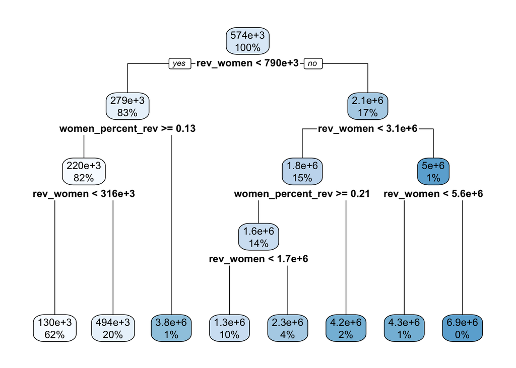

```r
rpart.plot::rpart.plot(womens_tree$fit)
```

```r
set.seed(0510)
mens_tree = decision_tree()%>%
  set_mode(mode = "regression") %>%
  fit(exp_men ~ rev_men + ef_male_count + partic_men + men_percent_partic   + men_percent_rev , data = mens_train)


tree_pred_test_mens= mens_tree %>%
  predict(new_data = mens_test)


mens_test %>%
  mutate(expense_men_pred = tree_pred_test_mens$.pred) %>%
  rmse(truth = exp_men, estimate = expense_men_pred)
```

```
## # A tibble: 1 × 3
##   .metric .estimator .estimate
##   <chr>   <chr>          <dbl>
## 1 rmse    standard     513647.
```

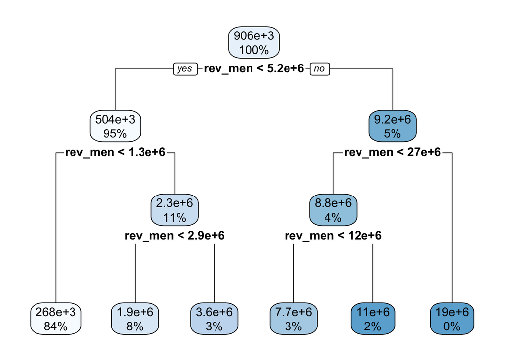

```r
rpart.plot::rpart.plot(mens_tree$fit)
```

The rMSE for the women’s tree model is: 313728.8

The rMSE for the men’s tree model is : 513646.6

## Cross-Validation

The rmse for the women’s training set for the decision tree is: 334969.0

The rmse for the men’s training set for the decision tree is: 565084.7

The two rmse’s for each team’s training set are very similar to those which were obtained from their respective tree models. This means that the training sets for both teams will not lead to overfitting in our models! Therefore, we can use the decision trees to determine the drivers of expense inequity between men’s and women’s collegiate basketball.

# Conclusions

You may have noticed that the men and women’s decision trees looks a bit different. The women’s tree includes 2 features (*revenue and percentage of total revenue*), with more branches, whereas the men’s tree only splits on one feature (*revenue*).

The following features were not included in either tree:

-ef_male_count/ef_female_count

-partic_men/partic_women

-men_partic_percent/women_partic_percent

Decision trees use an algorithm that determines which features are most prominent to the target, which in this case is the expenditure for teams. This means that from 2015-2019, the biggest factor in determining expenditures for men’s basketball teams was dependent on how much revenue they brought in. ‘Men_percent_rev’ was likely not added to the men’s tree as for most schools men’s teams generate much higher revenues, so the few schools where that was not the case, did not impact the model enough. Conversely, for schools in which their women’s team generated a higher revenue had an impact on the model.

```r
lm_womens_fit
```

```
## parsnip model object
##
##
## Call:
## stats::lm(formula = exp_women ~ rev_women + ef_female_count +
##     partic_women + women_percent_partic + women_percent_rev,
##     data = data)
##
## Coefficients:
##          (Intercept)             rev_women       ef_female_count
##            4.310e+05             6.862e-01             7.097e+01
##         partic_women  women_percent_partic     women_percent_rev
##            4.322e+03             2.207e+06            -3.257e+06
```

## Wrap-Up

Also, in my data wrangling/transformation step, I know that mutate functions seem overwhelming, and I wish I had mutated several variables within one ‘mutate()’ but when I was making the tables, I was just on a roll and did not have time to go back to make them prettier. But next time I will be more conscious of that while I am working.

Lastly, I had a fun time looking at this data set. It was my intention to incorporate title 9 data, or a similar data set to make my analysis more meaningful, but I was having a difficult time finding a comparable data table. If I had dedicated more time to this part I might have been able to come up with something, but I unfortunately did not leave myself enough time.

EXTRA FACT: When you search “college basketball” into the Google search engine, the first 62 images are of men’s teams. The 63rd image that depicts a woman is from an article from Boston University discussing the transfer of one of their players! Interesting, huh?